# 7 Statistiques Descriptives Univariées

### 7.4.3 Données quantitatives: Tendance centrale

Dans le cas de données quantitatives, il est possible d’obtenir non seulement le mode et la médiane, mais aussi la moyenne arithmétique de l’ensemble des données.

#### 7.4.3.1 Le mode

Une variable quantitative peut être formée de données discrètes ou continues. Dans le cas de données discrètes, on peut obtenir le mode de la même manière que pour les données qualitatives: il s’agit simplement de la valeur dont la fréquence est la plus élevée. Dans le cas de données continues, par contre, il est fréquent que les valeurs observées soient uniques et qu’il n’y ait que peu de valeurs égales. Par exemple, examinons un ensemble de 20 données choisies suivant une distribution Gaussienne dont la moyenne est 50 et l’écart-type est 8:

```r
x = round(rnorm(20,50,8), 2)
cat("Valeurs uniques:")
```

```
#> Valeurs uniques:
```

```r
unique(x)
```

```
#>  [1] 44.49 47.76 45.71 52.91 52.32 47.52 45.85 40.07 46.48 44.88 56.98 43.08
#> [13] 48.20 44.31 58.91 48.92 56.33 47.29 56.78 53.05
```

```r
cat("Nombre de valeurs uniques = ", length(unique(x)))
```

```
#> Nombre de valeurs uniques =  20
```

Par exemple, considérons la distribution d’un ensemble de 1000 données, illustrée à la Figure 7.17.

```r
x = rnorm(1000,50,8)
cat("Nombre de valeurs uniques = ", length(unique(x)))
```

```
#> Nombre de valeurs uniques =  1000
```

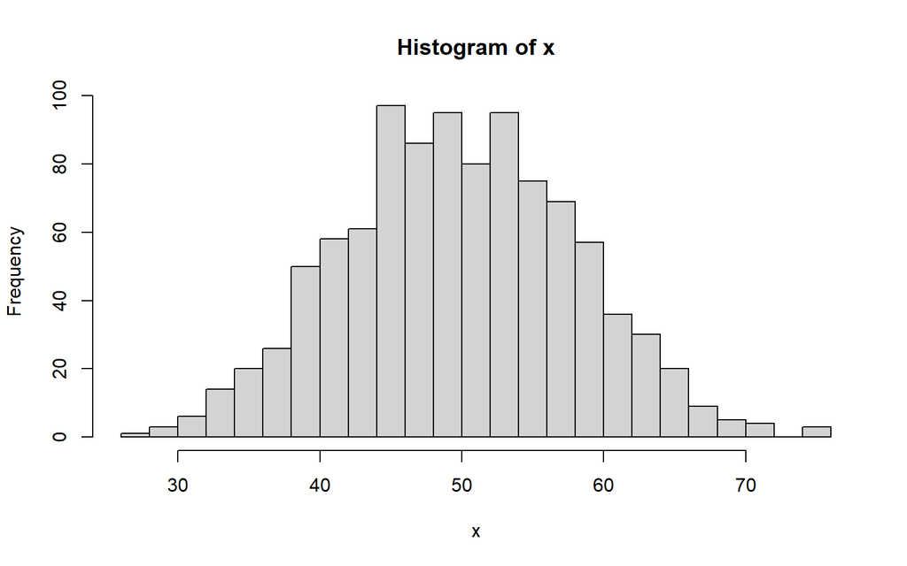

Figure 7.17: Distribution de 1000 données

```r
hist(x, breaks="FD")
```

Formellement, puisque chaque valeur de la distribution est unique, la distribution est amodale. Par contre, en obtenant la fonction de densité, on obtient le diagramme affiché à la Figure 7.18, et le mode correspond au score pour lequel la densité est la plus élevée, identifié par la ligne verticale rouge dans la figure Figure 7.18.

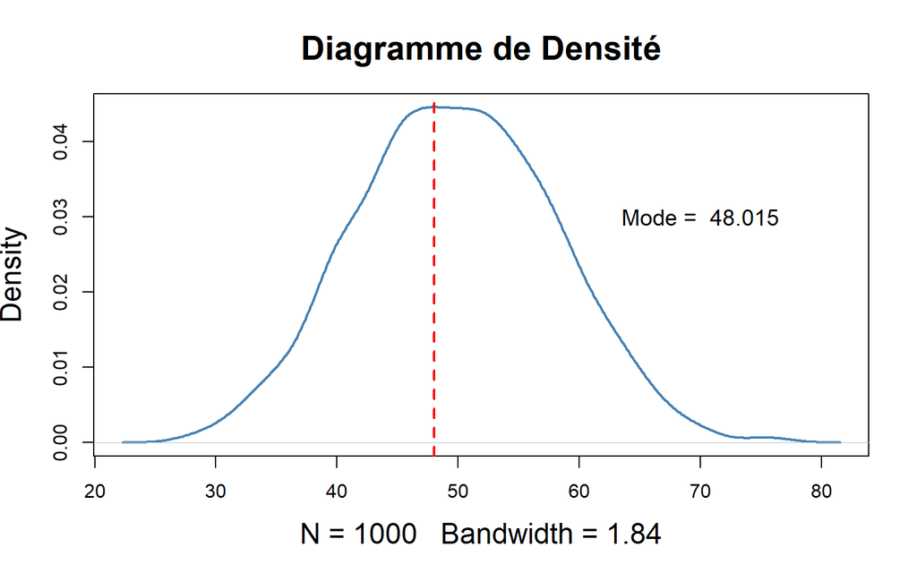

Figure 7.18: Fonction de densité

```r
dx = density(x, bw = "nrd0")
mo <- dx$x[which.max(density(x)$y)]
plot(dx,
     frame = TRUE,
     col = "steelblue",
     main = "Diagramme de Densité",
     cex.lab = 1.5,
     cex.main = 1.75,
     lwd = 2)
abline(v=mo, lty=2, lwd=2, col="red")
text(70, 0.03,paste("Mode = ", round(mo, 3)), cex=1.2)
```

À ce stade, on peut aisément développer une fonction pour déterminer le mode d’une variable quantitative continue. La fonction **DensMode()** (Listing 7.4) en est un exemple.

Pour les données à l’étude, on trouve:

```r
mo <-  DensMode(x)
cat("Mode = ", mo)
```

```
#> Mode =  48.01512
```

Alternativement, la fonction **mlv()** de la librairie **modeest** fait le travail avec davantage de versatilité:

```r
m = modeest::mlv(x,method="meanshift")
cat("Mode = ",m)
```

```
#> Mode =  48.01204
```

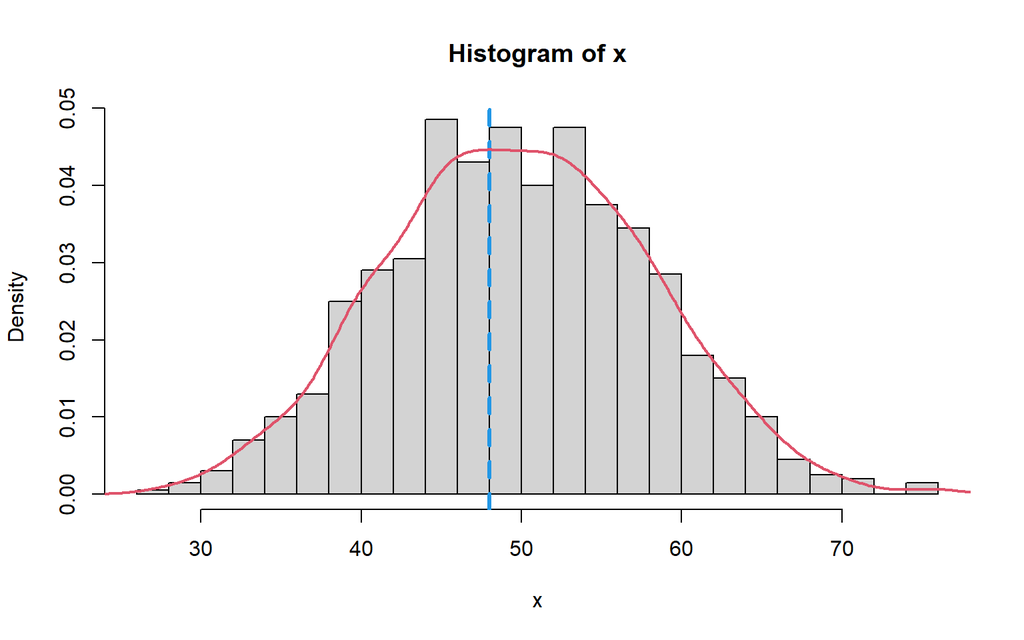

```r
hist(x, freq = FALSE,breaks="FD")
abline(v = m, col = 4, lty = 2, lwd = 3)

dx <- density(x)
lines(dx$x, dx$y, col = 2, lwd = 2)
```

Cette fonction offre différents algorithmes pour obtenir le mode d’une distribution (Lientz, Chernoff, Venter, Grenander, etc.). On pourra consulter la [documentation](https://www.rdocumentation.org/packages/modeest/versions/2.4.0) la concernant pour approfondir le sujet.

La librairie **multimode** est particulièrement intéressante pour l’examen du ou des modes dans une distribution continue.

Considérons une distribution bi-modale, créée à l’aide du code R suivant, et l’estimation des modes à partir de la courbe de densités:

```r
set.seed(23474567)
n <- 1000
bin <- rbinom(n, 1, 0.6)
y2 <- rnorm(n, mean = 80, sd = 11) * bin +
      rnorm(n, mean = 40, sd = 8) * (1 - bin)

modes <- multimode::locmodes(y2,
                             mod0 = 2,
                             lowsup=min(y2),
                             uppsup=max(y2))
modes
```

```
#>
#> Estimated location
#> Modes: 40.27793  79.98589
#> Antimode: 57.31064
#>
#> Estimated value of the density
#> Modes: 0.01827975  0.02139169
#> Antimode: 0.00518601
#>
#> Critical bandwidth: 2.635057
```

La Figure 7.19 représente la distribution de ces données sous forme d’histogramme. La courbe de densité correspondante est illustrée à la Figure 7.20 :

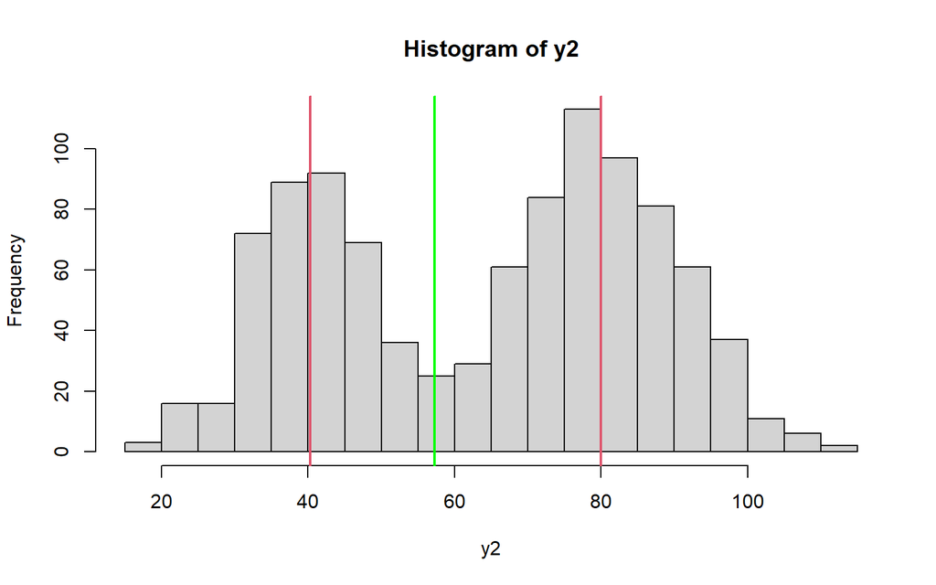

Figure 7.19: Histogramme: Distribution bimodale

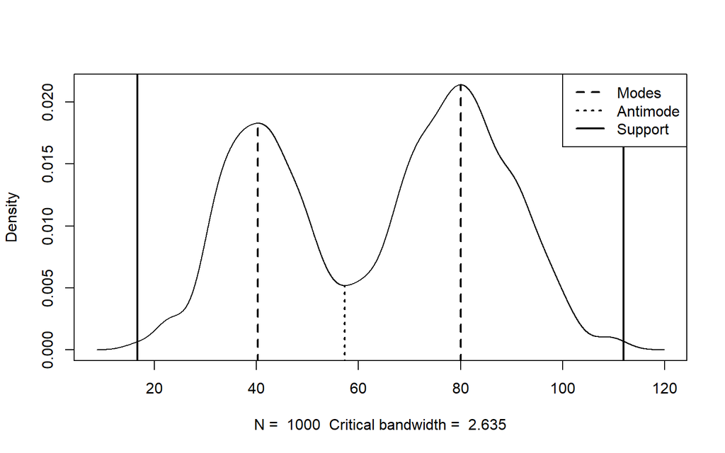

Figure 7.20: Courbe de densité: Distribution bimodale

De la fonction de densité, on estime l’existence de deux modes dont les valeurs sont respectivement 40.28 et 79.99 et sont associés à des densités similaires (0.018 et 0.021). L’antimode se trouve à x = 57.31, avec une densité très faible (0.005). L’histogramme et la courbe de densité illustrent la situation. Les deux modes sont affichés, de même que l’**antimode**, la valeur dont la densité est la plus faible, entre deux modes, lorsque la distribution est bi- ou multimodale. Les droites verticales libellées **support** représentent les limites (inférieure et supérieure) entre lesquelles un mode est recherché (dans le cas présent, il s’agit simplement du minimum et du maximum de la distribution).

#### 7.4.3.2 La médiane

Pour la médiane et les quartiles, on peut utiliser à nouveau les fonctions **quantile()** et **summary()** comme on l’a fait pour des données ordinales. Par exemple,

```r
x = runif(500,1,50)
cat("La médiane est ",median(x))
```

```
#> La médiane est  24.47717
```

```r
cat("Les quartiles sont :\n ",quantile(x,c(0.25,0.5,0.75)))
```

```
#> Les quartiles sont :
#>   11.66862 24.47717 37.0635
```

```r
summary(x)
```

```
#>    Min. 1st Qu.  Median    Mean 3rd Qu.    Max.
#>   1.101  11.669  24.477  24.635  37.063  49.974
```

#### 7.4.3.3 La moyenne

On peut obtenir la moyenne à l’aide de la fonction **mean()**:

```r
cat("La moyenne est égale à ",mean(x))
```

```
#> La moyenne est égale à  24.63452
```

On se souviendra que la moyenne est le centre de gravité d’un ensemble de scores. De ce fait, la somme des écarts par rapport à sa valeur sera toujours nulle:
$$\sum_{i = 1}^{n}(X - \overline{X})=0$$
Pour le vérifier:

```r
cat("La somme des écarts à la moyenne = ", round(sum(x-mean(x))), 5)
```

```
#> La somme des écarts à la moyenne =  0 5
```

### 7.4.4 Données quantitatives: Dispersion

L’écart inter-quartile permettant de quantifier la dispersion d’une variable ordinale peut s’obtenir de la même manière pour une variable quantitative. Par contre, on préférera un indice plus efficace dans le cas de variables de ce niveau (mesure d’intervalle ou de rapport). Il s’agit ici d’utiliser toute l’information disponible pour obtenir un indice fiable de l’éparpillement des données autour du centre de la distribution.

On peut facilement imaginer qu’un tel indice doit se fonder sur les distances qui séparent chaque donnée du centre de la distribution. Puisque la médiane et la moyenne représentent ce centre (quoique d’une manière conceptuellement distincte!), notre attention se portera soit sur $(X - Md)$, soit sur $(X - \bar X)$. Mais puisque $\sum (X - \bar X)=0$, il faudra trouver une manière de ne considérer que les distances **absolues** séparant les données du centre. Les candidats qui satisfont ce critère sont:  
1. La déviation médiane:

$$\sum_{i=1}^{n}\frac{\left | X_{i}-Md \right|}{n} \tag{7.16}$$

Cette mesure est simplement la moyenne arithmétique des écarts par rapport à la médiane.

2. La déviation moyenne:

$$\sum_{i=1}^{n}\frac{\left | X_{i}-\bar{X} \right|}{n} \tag{7.17}$$

Cette mesure est très similaire à la précédente: il s’agit de la moyenne arithmétique des écarts par rapport à la moyenne.

3. La variance:

$$s^{2} = \frac{\sum_{i=1}^{n}\left(X_{i} - \bar{X}\right)^{2}}{n-1} \tag{7.18}$$

Cette mesure est analogue à la déviation moyenne, sauf que les écarts absolus par rapport à la moyenne sont remplacés par le carré de ces quantités. On note aussi qu’au niveau du dénominateur, une correction est apportée $(n-1)$. Ce point particulier sera explicité plus tard. On obtient de cette manière une moyenne arithmétique des carrés des écarts par rapport à la moyenne.

4. L’écart-type:

$$s = \sqrt{\frac{\sum\limits_{i=1}^{n} \left(X_{i} - \bar{X}\right)^{2}} {n-1}} \tag{7.19}$$

Cette mesure de dispersion, omniprésente dans les méthodes d’analyse de données quantitatives n’est que la racine carrée de la variance. Donc la racine carrée de la moyenne des carrés des écarts par rapport à la moyenne.

```r
cat("La déviation moyenne = ",mad(x,center=mean(x)))
```

```
#> La déviation moyenne =  18.93523
```

```r
cat("La déviation médiane = ",mad(x,center=median(x)))
```

```
#> La déviation médiane =  18.98868
```

```r
cat("La variance          = ",var(x))
```

```
#> La variance          =  201.1866
```

```r
cat("L'écart-type         = ",sd(x))
```

```
#> L'écart-type         =  14.18403
```

5. Le Coefficient de Variation: ce coefficient est une mesure de dispersion **relative**. Il est défini par:

$$CV = \frac {\sigma}{\bar X}\times 100 \tag{7.20}$$

6. Le coefficient de variation robuste: Ce coefficient est analogue au coefficient de variation, sauf qu’il n’est pas affecté par les données extrêmes: il utilise la médiane et la déviation médiane absolue:

$$CVR =\frac {Déviation Médiane}{Médiane}\times 100 \tag{7.21}$$

#### 7.4.4.1 Exercice 5:

7. Générez un ensemble de 500 observations gaussiennes avec une moyenne avoisinant 50 et un écart-type avoisinant 10.
8. Obtenez les indices de tendance centrale: moyenne et médiane
9. Obtenez les indices de dispersion
10. Obtenez les indices de symétrie et de voussure
11. Obtenez la distribution des fréquences et les représentations graphiques habituelles
12. Sous quel score trouve-t-on 67% de la distribution?
13. Quelle est la proportion des scores de la distribution sous X = 40?
14. Quelle est la probabilité, en choisissant une observation au hasard, d’obtenir un score inférieur à 35, ou supérieur à 65?
15. Déterminez les valeurs limitant les 95% centraux de la distribution.
16. Quelle est la proportion des scores compris entre 38 et 57?

## 7.5 Distributions de probabilité: Variables quantitatives continues

### 7.5.1 La distribution uniforme

La distribution des événements survenant au lancer d’un dé non truqué, on l’a vu, inclus six résultats équiprobables: la probabilité d’obtenir une face particulière du dé est égale à 1/6 pour chacune des faces possibles. On peut donc qualifier cette distribution discrète de **uniforme** ou **rectangulaire**. Lorsque le nombre d’événements possibles est infini (ou très grand), et que l’équiprobabilité est maintenue, les mêmes qualificatifs s’appliquent, pour une distribution **continue**.

La distribution uniforme continue est délimitée par une valeur minimale, et une valeur maximale. Ce sont les deux seuls paramètres de cette distribution. Par exemple, considérons la durée du vol reliant Montréal à Port-au-Prince. Au cours des 5 dernières années, les statistiques indiquent que le temps de vol le plus court a été de 212 minutes, alors que le temps le plus long a été de 278 minutes. Tous les vols effectués durant cette période ont impliqué une durée comprise entre ces deux valeurs. La figure suivante illustre la situation:

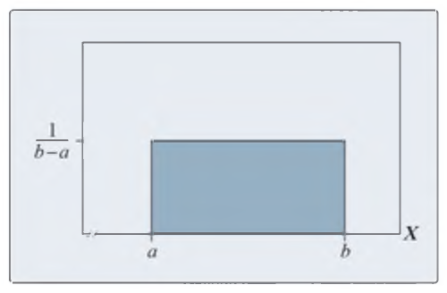

Distribution Uniforme

Dans de graphique, *a* représente la limite inférieure de la distribution (temps de vol = 212 minutes), et *b* représente la limite supérieure (temps de vol = 278 minutes). Entre ces deux extrêmes, on trouve un nombre infini de valeurs dont les probabilités d’occurrence sont les mêmes, tel que défini dans l’équation Équation 7.22.

$$P(x)=
\begin{cases}
\frac{1}{b-a}\times(x_1-x_0) & si~~a\le x \le b \\
0 & sinon
\end{cases}
\tag{7.22}$$

Cette définition indique que pour une valeur donnée de *x* (c’est-à-dire pour un intervalle $[x_1-x_0]$ très petit), $P(x)=\frac{1}{b-a}$, pour autant que *x* se trouve à l’intérieur des limites de la distribution. La probabilité est nulle dans le cas contraire. On peut donc dire qu’un vol entre Montréal et Port-au-Prince a autant de chance de durer 212 minutes que 253 minutes.

Comme toute distribution de probabilité, la distribution uniforme possède une espérance mathématique et une certaine variabilité, lesquelles sont définies par les équations Équation 7.23 et Équation 7.24, respectivement.

$$E(x)=\frac{a+b}{2} \tag{7.23}$$

$$\sigma (x)=\sqrt{\frac{{{(b-a)}^{2}}}{12}} \tag{7.24}$$

Pour la distribution des durées de vol entre Montréal et Port-au-Prince, on trouve:

$$E(x)=\frac{212+278}{2}=245$$
$$\sigma (x)=\sqrt{\frac{{{(278-212)}^{2}}}{12}}=19.053$$

Ces notions nous permettent de répondre à des questions telles que:

- Quelle est la probabilité que la durée de vol entre Montréal et Port-au-Prince soit inférieure à 240 minutes?

$$P(x<240)= \frac{1}{278-212}\times {(240-212)}=0.424$$

$$P(235<x<255)= \frac{1}{278-212}\times {(255-235)}=0.303$$

Sous R, les fonctions suivantes permettent l’examen de la distribution uniforme:

- **dunif(x, min, max)**: Calcul de la probabilité de *x*
- **punif(q, min, max, lower.tail=TRUE)**: Calcul de la probabilité cumulative
- **qunif(p, min, max, lower.tail=TRUE)**: Calcul du percentile
- **runif(n, min, max)**: Génération de *n* nombres aléatoires

Ainsi, reprenant les exemples précédents, on trouve:

```r
x <- dunif(240, 212, 278) # Probabilité d'une durée de vol donnée
cat("P(x = 240) = ", x)
```

```
#> P(x = 240) =  0.01515152
```

```r
x <- punif(240, 212, 278, lower.tail=TRUE) # P(durée de vol < 240 minutes)
cat("P(x < 240) = ", x)
```

```
#> P(x < 240) =  0.4242424
```

```r
x <- qunif(0.75, 212, 278, lower.tail=TRUE) # Troisième quartile (Q3)
cat("Q3 = ", x)
```

```
#> Q3 =  261.5
```

```r
x <- runif(5, 212, 278) # Séquence de durées de vol aléatoires
cat("Nombres aléatoires : ", x)
```

```
#> Nombres aléatoires :  265.6455 251.2263 268.6209 273.9098 228.6271
```

### 7.5.2 La distribution gaussienne (Normale)

La distribution binomiale a été présentée dans le chapitre 6. On se rappellera que cette distribution concerne des événements discrets résultant d’expériences aléatoires dont les résultats sont binaires. Lorsque le nombre de ces événements est infini (ou très élevé), on obtient une distribution continue dont la forme, déjà, nous est familière. Cette distribution est qualifiée de **normale**, ou **gaussienne**.

Par exemple, considérons la taille des femmes de 20 ans, mesurée en centimètres (données de 2015), illustrée par la Figure 7.21:

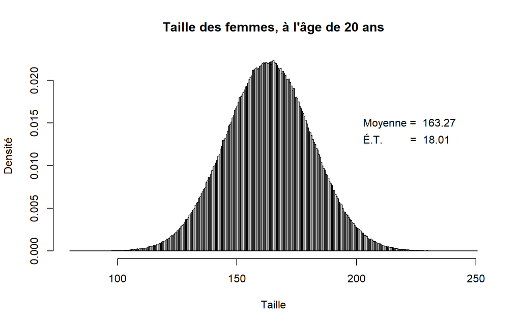

Figure 7.21: Distribution de la taille des femmes âgées de 20 ans. La distribution est qualifiée de normale, ou gaussienne.

```r
x <- rnorm(1000000,163.3,18)

hist(x,
     breaks="FD",
     main="Taille des femmes, à l'âge de 20 ans",
     xlab="Taille",
     ylab="Densité",
     freq=FALSE)
text(200, 0.015, label = paste("Moyenne = ", round(mean(x), 2)), pos = 4)
text(200, 0.013, label = paste("É.T.         = ", round(sd(x),2)), pos = 4)
```

Dans une section précédente, il nous a été possible de calculer certaines probabilités en comptabilisant de manière empirique, le nombre de cas se trouvant à l’intérieur d’une certaine zone de la distribution. Sans surprise, on trouvera une manière analytique d’effectuer le même travail. Il suffit de considérer la définition mathématique de cette distribution (équation Équation 7.25).

$$f(x) = \frac{1}{\sigma \sqrt{2\pi }} e^{-\frac{(X-\mu)^2}{2{\sigma }^2}} \tag{7.25}$$

La formulation peut paraître complexe, mais elle est constituée de plusieurs constantes (*e* = 2.71828, $\pi$ = 3.14159, 2), d’une variable (*X*), et de deux paramètres essentiels, qui la définissent: la **moyenne** ($\mu$) et l’**écart-type** ($\sigma$). Il s’agit d’une distribution théorique permettant la description de la distribution de plusieurs variables aléatoires continues.

Reconsidérant l’équation Équation 7.25, il est utile de constater que $z=\frac{X - \mu}{\sigma}$ est au coeur de la définition formelle de la fonction de densité Normale :

$$f(x) = \frac{1}{\sigma \sqrt{2\pi }} e^{-\frac{1}{2} \left[ \color{red}{\frac{X-\mu}{\sigma} }\right] ^2} \quad , \, \forall \quad -\infty < x< \infty \tag{7.26}$$

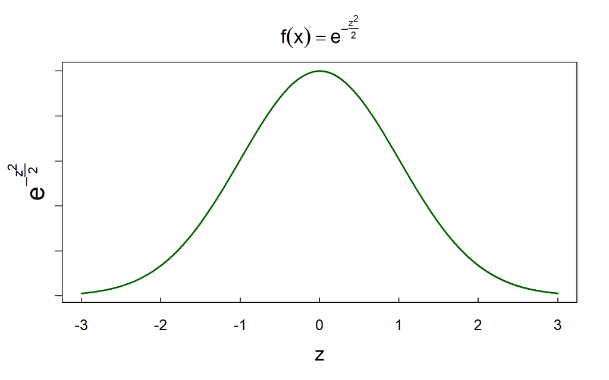

Fonction Gaussienne

Le paramètre $\mu$ détermine la position de la courbe sur l’axe horizontal, alors que le paramètre $\sigma$ en détermine l’étalement, sur cet axe.  
On pourra démontrer que l’aire totale sous cette fonction est égale à:

$$\int_{-\infty}^{\infty}e^{-\frac{1}{2}z^2}\,dz = \sqrt{2\pi}$$

de sorte qu’en calculant

$$f(x) = \frac{1}{\sqrt{2\pi }} e^{-\frac{1}{2} z^2}$$

Sous R, la fonction **integrate()** permet cette opération:

```r
# Définition de la fonction
f <- function(x) {1/sqrt(2*pi)*exp(-x^2/2)}

# Integration de la fonction
## integrate(f, lower = -Inf, upper = Inf)
integrate(f, lower = -1.96, upper = 1.96)
```

```
#> 0.9500042 with absolute error < 0.00000000001
```

De manière générale, la fonction de densité cumulative permettant le calcul de l’aire sous une courbe normale caractérisée par $\mu$ et $\sigma$, entre deux points $a$ et $b$, est définie par:

$$\displaystyle cdf(a,b,\mu,\sigma) = \int_a^b \frac{1}{ \sigma \sqrt{2 \pi}} e^{\left[-\frac{{\left(x - \mu\right)}^{2}}{2 \, \sigma^{2}}\right]} dx \tag{7.27}$$

La fonction de densité cumulative, couvrant l’aire comprise entre $-\infty$ et $x$, sous la courbe, s’obtient à l’aide de l’intégration:

$$\Phi(x)={\frac{1}{\sqrt{2\pi}}}\int_{-\infty}^{x}e^{-\frac{1}{2} \left[ \frac{X-\mu}{\sigma} \right] ^2}\,dx \tag{7.28}$$

La Figure 7.22 illustre des distributions gaussiennes variant quant à la moyenne (position sur l’axe horizontal), et la Figure 7.23 montre des distributions variant quant à la dispersion.

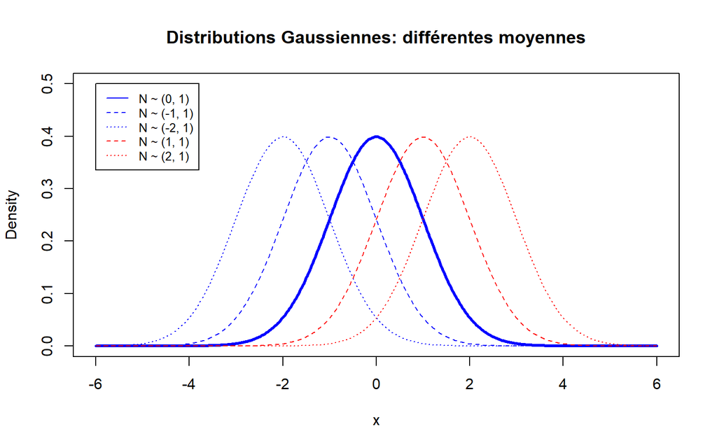

Figure 7.22: Distributions normales: moyennes différentes

```r
x <- seq(-6, 6, length=500)
plot(x,
     dnorm(x,mean=0,sd=1),
     type = "l",
     lty=1,
     lwd=3,
     col="blue",
     main="Distributions Gaussiennes: différentes moyennes",
     ylim=c(0,0.5),
     xlim=c(-6,6),
     ylab="Density")
curve(dnorm(x,-1,1),
      add=TRUE,
      lty=2,
      col="blue")
curve(dnorm(x,-2,1),
      add=TRUE,
      lty=3,
      col="blue")
curve(dnorm(x,1,1),
      add=TRUE,
      lty=2,
      col="red")
curve(dnorm(x,2,1),
      add=TRUE,
      lty=3,
      col="red")
legend(-6,.5,
       legend=c("N ~ (0, 1)","N ~ (-1, 1)","N ~ (-2, 1)","N ~ (1, 1)","N ~ (2, 1)"),
       lty=c(1:3,2, 3),
       cex=0.8,
       col=c("blue", "blue", "blue", "red", "red"))
```

[figure not shown]

Figure 7.23: Distributions normales: variances différentes

```r
x <- seq(-6,6,length=500)
plot(x,
     dnorm(x,mean=0,sd=1),
     type = "l",
     lty=1,
     lwd=3,
     col="black",
     main="Distributions Gaussiennes: différentes variances",
     ylim=c(0,0.8),
     xlim=c(-6,6),
     ylab="Density")
curve(dnorm(x, 0, 0.5),
      add=TRUE,
      lty=2,
      col="red")
curve(dnorm(x,0, 2),
      add=TRUE,
      lty=2,
      col="blue")
curve(dnorm(x,0, 4),
      add=TRUE,
      lty=2,
      col="green")
legend(-6, .8,
       legend=c("N ~ (0, 1)","N ~ (0, 0.8)","N ~ (0, 2)", "N ~ (0, 4)"),
       lty=c(1, 2, 2, 2),
       cex=0.8,
       col=c("black","red", "blue", "green"))
```

Cette distribution possède, en théorie, les propriétés suivantes:

- Elle est symétrique autour de son centre
- Elle est unimodale
- La moyenne, le mode et la médiane coïncidents, conséquence de la symétrie
- Elle est mésokurtique, les extrémités ayant une ‘lourdeur’ intermédiaire
- Elle est asymptotique par rapport à l’axe définissant la variable concernée
- L’aire sous la courbe est égale à l’unité: 100% des observations se trouvent à l’intérieur des limites de la distribution.

Ces premières propriétés sont illustrées dans la Figure 7.24:

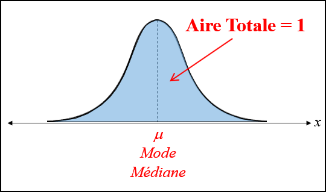

Figure 7.24: Distribution normale: Propriétés I

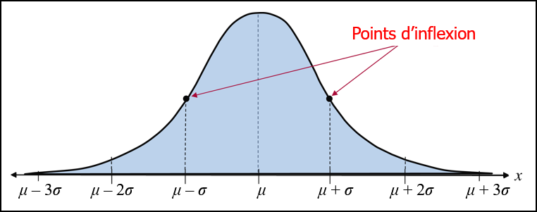

Figure 7.25: Distribution normale: Propriétés II

```r
knitr::include_graphics("./images/DistrNorm2.png")
```

Rappelons que la distribution normale est caractérisée uniquement par sa moyenne (position du centre sur l’axe définissant la variable) et son écart-type (quantifiant la dispersion de la distribution). De ce fait, une distribution normale distincte existe pour chaque combinaison de valeurs possibles de moyennes et d’écarts-types: il existe un nombre infini de telles distributions!

Une variable dont la distribution s’apparente à la distribution normale théorique sera qualifiée de **normalement distribuée**, avec une certaine moyenne et un certain écart-type. Utilisant une notation mathématique, on écrira:

$$Y\sim N(\mu,\sigma)$$

Pour la distribution de la taille des femmes âgées de 20 ans, on écrira:

$$Y\sim N(163.27, 18.01)$$

Dans une distribution normale, l’écart-type joue un rôle essentiel. Il représente en effet une unité métrique que l’on peut utiliser pour positionner un score donné sur l’axe définissant la variable. Puisque l’écart-type partage la même unité de mesure que la variable elle-même, on peut formuler la position d’un score en unité d’écart-type! Ainsi, on dira qu’un score donné se trouve à 1.5 écart-type de la moyenne. La figure précédente permet de visualiser ce fait: on y situe, sous la courbe, les points correspondant à des scores situés à -3$\sigma$, -2$\sigma$, …, +2$\sigma$, +3$\sigma$. Bref, on peut effectuer la conversion de tout score brut en **score standardisé** utilisant l’écart-type comme unité de mesure. Il suffira de calculer les scores Z, omniprésents dans la littérature statistique et définis par l’équation Équation 7.29.

$$Z=\frac{X-\bar X}{\sigma} \tag{7.29}$$

Le numérateur est simplement la distance séparant une donnée de la moyenne de la distribution, et en divisant cette distance par l’écart-type, on la standardise de manière à ce que l’écart-type lui-même en devienne l’unité de mesure.

Si chacune des données formant un ensemble est transformée en score Z, alors on obtient une distribution normale standardisée, dont la moyenne sera nulle (car les données sont centrées sur la moyenne), et l’écart-type est égal à 1. La forme de la distribution demeurera inchangée. Donc on peut écrire la relation décrite par l’équation Équation 7.30.

$$X \sim N(\mu,\sigma)\Rightarrow Z=\frac{X-\mu}{\sigma}\sim N(0,1) \tag{7.30}$$

Comme c’est le cas pour chaque distribution de probabilités étudiées jusqu’ici, R offre plusieurs fonctions nous permettant le calcul de probabilités relatives à des variables normalement distribuées:

- **dnorm**(x, mean = 0, sd = 1): Calcul de la probabilité de x
- **pnorm**(q, mean = 0, sd = 1, lower.tail = TRUE): Calcul de la probabilité cumulative inférieure (par défaut) ou supérieure
- **qnorm**(p, mean = 0, sd = 1, lower.tail = TRUE): Calcul du score sous (par défaut) ou au-dessus duquel on trouve $(100\times p)\%$ de la distribution
- **rnorm**(n, mean = 0, sd = 1): Génération de nombres aléatoires.

Examinons quelques exemples pour nous familiariser avec cette distribution.

#### 7.5.2.1 Exemple 1

Quelle est la probabilité, en choisissant une femme de 20 ans au hasard, qu’elle mesure 175 centimètres? Rappelons que la moyenne de cette distribution est égale à 163.27, et que son écart-type est égal à 18.01. Notons également que dans le cas d’une distribution continue, la probabilité d’occurrence d’une valeur particulière est nulle ($P(X = x) = \frac{1}{\infty}=0$). En conséquence, la probabilité obtenue correspond à $P(174.5 < Taille < 175.5)$.

```r
x <- dnorm(175, 163.27, 18.01)
cat("P(X  =  175) = ", x)
```

```
#> P(X  =  175) =  0.01791773
```

#### 7.5.2.2 Exemple 2

Quelle est la probabilité, en choisissant une femme de 20 ans au hasard, qu’elle mesure plus que 175 centimètres?

```r
x <- pnorm(175, 163.27, 18.01, lower.tail=FALSE)
cat("P(X  >  175) = ", x)
```

```
#> P(X  >  175) =  0.2574249
```

Graphiquement, on peut représenter cette situation par une courbe de densité:

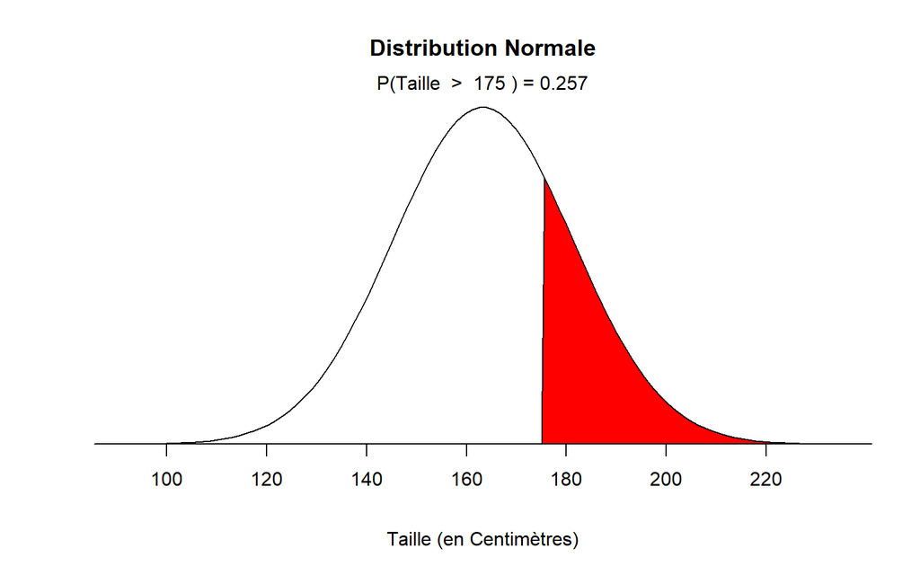

#### 7.5.2.3 Exemple 3

Quelle est la proportion des femmes de 20 ans qui mesurent moins de 140 centimètres?

[figure not shown]

```r
x <- pnorm(140, 163.27, 18.01, lower.tail=TRUE)
cat("P(X < 140) = ", x)
```

```
#> P(X < 140) =  0.09816819
```

#### 7.5.2.4 Exemple 4

Quelle est la proportion des femmes de 20 ans qui mesurent entre 180 et 200 centimètres?

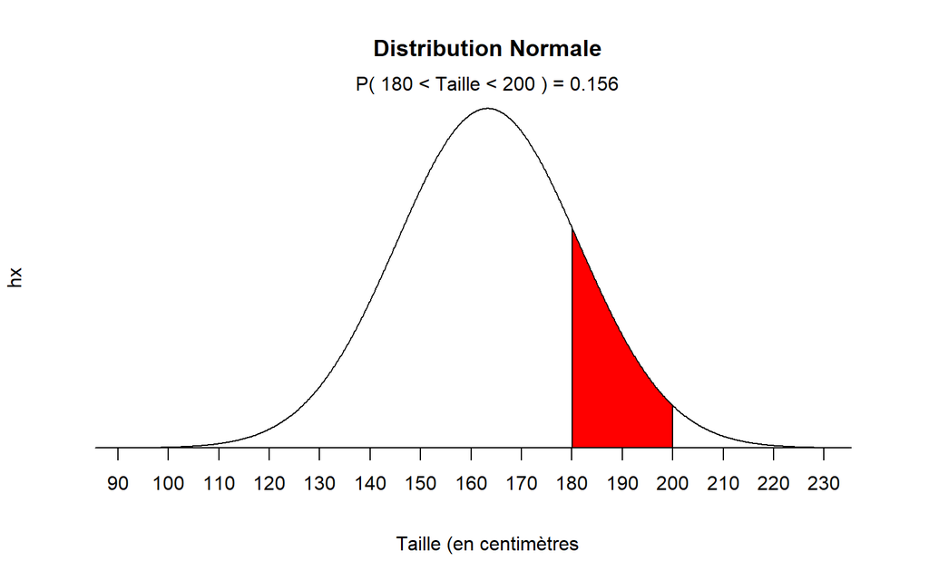

```r
x1 <- pnorm(200, 163.27, 18.01, lower.tail=TRUE)
x2 <- pnorm(180, 163.27, 18.01, lower.tail=TRUE)
cat("P(X > 150) = ", x1-x2)
```

```
#> P(X > 150) =  0.1557592
```

#### 7.5.2.5 Exemple 5

Quelle est la taille sous laquelle 75% des femmes de 20 ans se trouvent? En d’autres termes, quel est le 75ième percentile (ou le troisième quartile)?

```r
x <- qnorm(0.75, 163.27, 18.01, lower.tail=TRUE)
cat("P75 (Q3) = ", x)
```

```
#> P75 (Q3) =  175.4176
```

Le graphique suivant représente la distribution de probabilité cumulative, à partir de laquelle on obtient aisément tant les percentiles que les rangs centiles, On note ici que 75% des femmes de 20 ans mesurent moins de 175.42 centimètres. Le **Rang Centile (RC)** est égal à 75%, alors que le 75ième **percentile** (P75) est égal à 175.42.

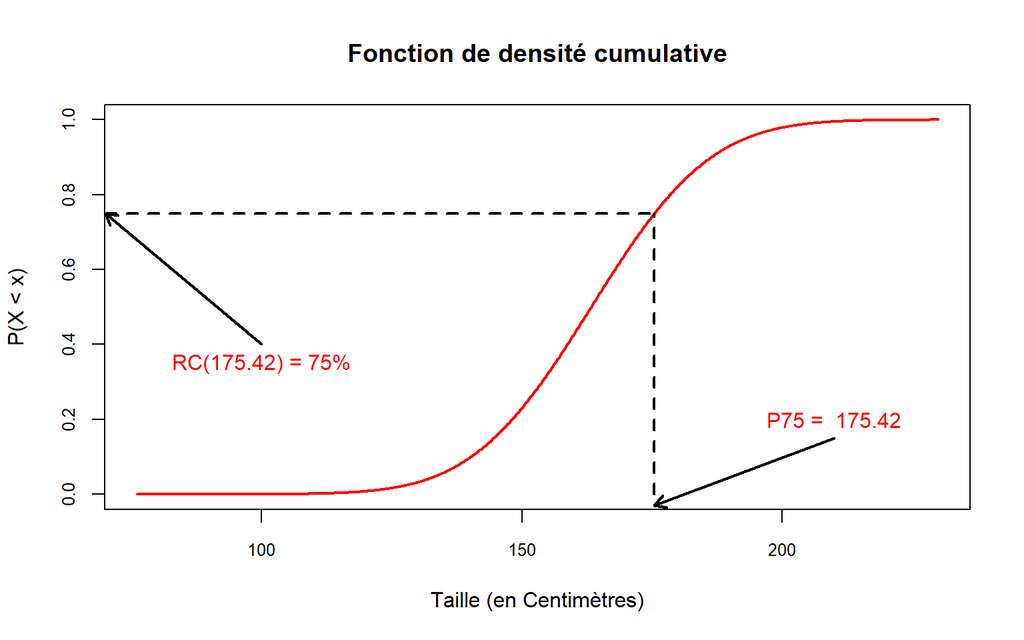

### 7.5.3 La distribution exponentielle

Nous avons présenté une distribution discrète pertinente dans les cas où on s’intéresse à la fréquence d’un événement durant une période de temps déterminée, ou dans une zone géographique précise, ou à l’intérieur d’un intervalle de temps ou d’espace particulier. La distribution de Poisson s’était avérée particulièrement utile dans ces cas.

Lorsqu’une variable continue mesure l’importance d’un événement survenant dans un intervalle de temps donné, ou le passage du temps avant qu’un événement se produise, on pourra considérer la distribution exponentielle. En effet, une variable aléatoire exponentielle mesure souvent le passage du temps. Par exemple,  
- quelle est la probabilité qu’un événement donné survienne entre minuit et 6:00 heures le matin?  
- quelle est la probabilité qu’un événement prenne plus que 2 heures à se produire?

En bref, X = le temps écoulé entre des événements, ou le passage du temps avant qu’un événement se produise.

Une variable aléatoire exponentielle X reflète donc le fait que les valeurs faibles de X sont plus fréquentes que les valeurs plus élevées.

La définition mathématique de la distribution exponentielle ne dépend que d’un seul paramètre: le nombre d’occurrences moyen par unité de temps (ou d’espace). L’équation Équation 7.31 fournit une définition formelle de cette distribution.

$$P(x)=
\begin{cases}
0 & si~~X<0 \\
\lambda e^{-\lambda X} & si ~~ X\ge 0
\end{cases}
\tag{7.31}$$

L’espérance mathématique de la distribution exponentielle est la réciproque du taux moyen, $\lambda^{-1}$ et sa variance est la réciproque de son carré, $Var(x)=\frac{1}{\lambda^2}$. L’écart-type est donc égal à l’espérance mathématique, dans ce cas. La Figure 7.26 illustre la forme de la distribution, en fonction de la valeur de $\lambda$.

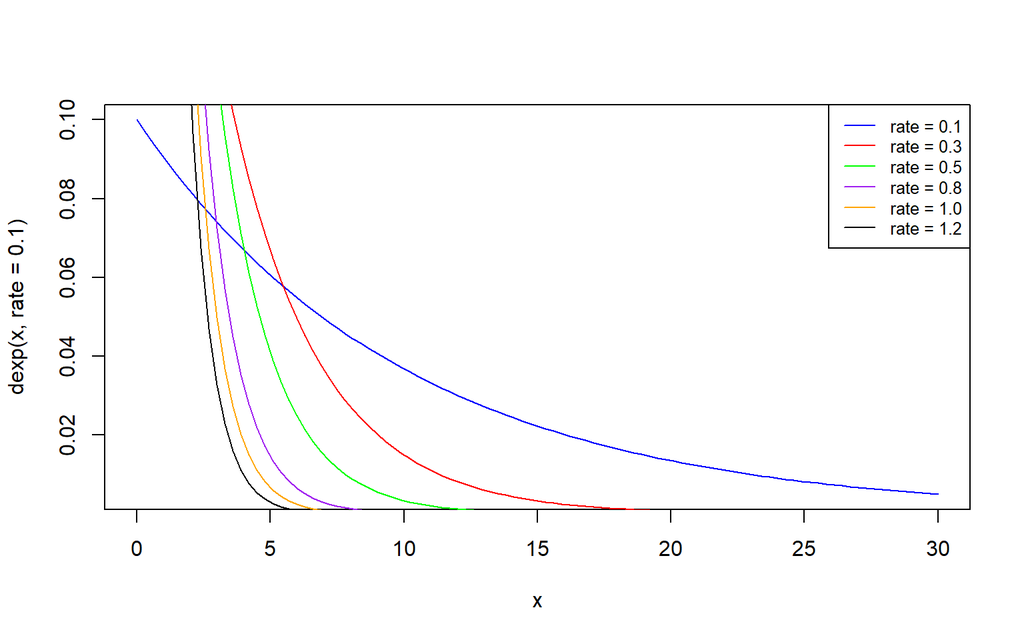

Figure 7.26: Distribution exponentielle, en fonction de λ

```r
curve(dexp(x, rate = 0.1), from=0, to=30, col='blue')
curve(dexp(x, rate = 0.3), from=0, to=30, col='red', add=TRUE)
curve(dexp(x, rate = 0.5), from=0, to=30, col='green', add=TRUE)
curve(dexp(x, rate = 0.8), from=0, to=30, col='purple', add=TRUE)
curve(dexp(x, rate = 1.0), from=0, to=30, col='orange', add=TRUE)
curve(dexp(x, rate = 1.2), from=0, to=30, col='black', add=TRUE)

legend("topright",
       legend=c("rate = 0.1", "rate = 0.3", "rate = 0.5", "rate = 0.8", "rate = 1.0", "rate = 1.2" ),
       col=c("blue", "red", "green", "purple", "orange", "black"), lty=1, cex=0.8)
```

Quelle serait la probabilité qu’un client passe au plus 7 minutes dans le commerce? Le graphique présenté à la Figure 7.27 illustre la situation, utilisant la fonction Listing 7.6.

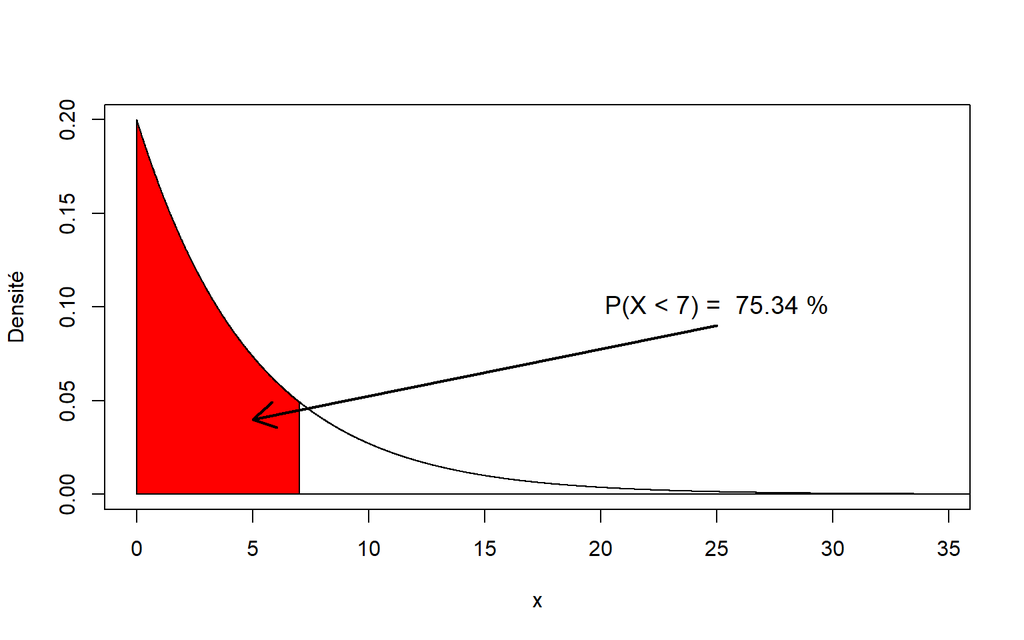

Figure 7.27: Probabilité qu’une visite s’étale sur au plus 7 minutes

```r
exp_area(rate=0.2,ub=7, acolor="red")
x <- seq(0, 60, length = 100)
lines(x,rep(0,length(x)))
pr <- pexp(7, rate=0.2, lower.tail=TRUE)
tx <- paste("P(X < 7) = ",round((100*pr),3),"%")
text(25, 0.1, tx, col = "black", cex = 1.2)
arrows(25, 0.09, 5, 0.04, length=0.2, lwd=2)
lines(x,rep(0,length(x)))
```

La probabilité recherchée serait dans ce cas égale à:

$$P(X < 7)=1-e^{-0.2(7)}=0.753$$

Quelle est la probabilité que la durée d’une interaction entre un client et le commis soit comprise entre 7 et 12 minutes? La Figure 7.28 en présente les détails.

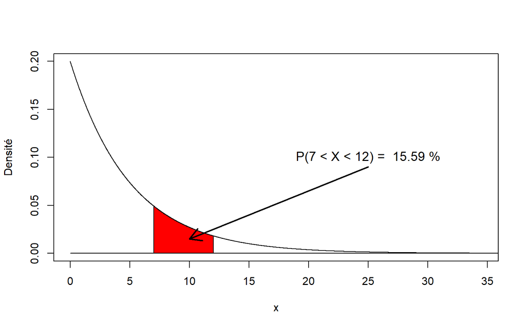

Figure 7.28: Probabilité qu’une interaction dure entre 7 et 12 minutes

```r
exp_area(rate=0.2, lb=7, ub=12, acolor="red")
x <- seq(0, 60, length = 100)
lines(x,rep(0,length(x)))
pr1 <- pexp(12, rate=0.2, lower.tail=TRUE)
pr2 <- pexp(7, rate=0.2, lower.tail=TRUE)
tx <- paste("P(7 < X < 12) = ", round(100*(pr1-pr2),1.5),"%")
text(25, 0.1, tx, col = "black", cex = 1.2)
arrows(25, 0.09, 10, 0.015, length=0.2, lwd=2)
lines(x,rep(0,length(x)))
```

Les fonctions disponibles pour étudier cette distribution, analogues à celles présentées pour les distributions précédentes, sont:

- **dexp(x, rate=1)**: Fonction de densité de probabilité
- **pexp(x, rate=1, lower.tail=TRUE)**: Fonction de distribution cumulative
- **qexp(p, rate=1, lower.tail=TRUE)**: Fonction quantile de la distribution exponentielle
- **rexp(n, rate=1)**: Génération de nombres aléatoires suivant la distribution exponentielle

Les quantités recherchées à l’aide des fonctions dexp(), pexp() et qexp() sont illustrées dans la Figure 7.29:

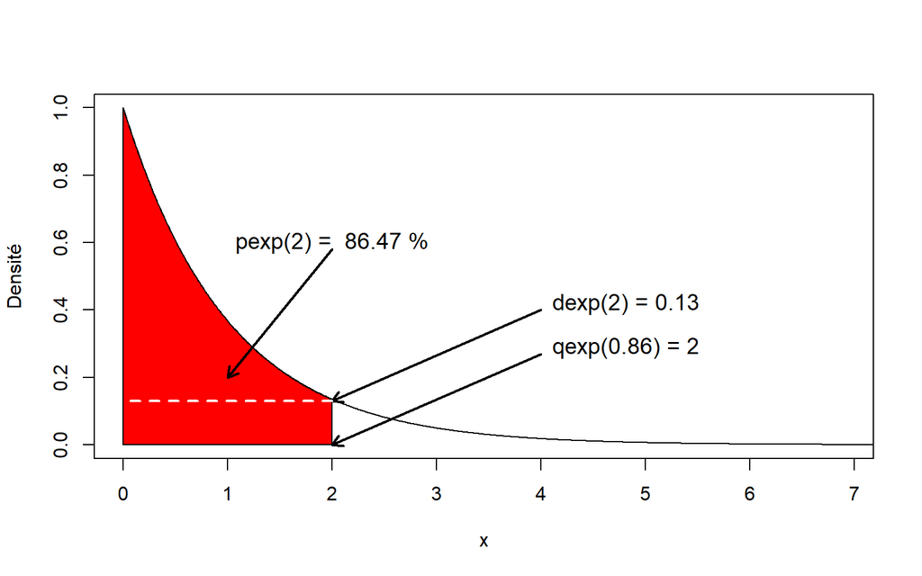

Figure 7.29: Fonctions R relatives à la distribution Exponentielle: X=2, λ = 1

```r
exp_area(rate=1, ub=2, acolor="red")
pr <- pexp(2, rate=1, lower.tail=TRUE)
tx <- paste("pexp(2) = ",round((100*pr),2),"%")
text(2, 0.6, tx, cex = 1.2)
arrows(2, 0.58, 1, 0.2, length=0.1, lwd=2)
arrows(4, 0.4, 2, 0.13, length=0.1, lwd=2)
segments(2, 0.13, 0, 0.13, col="white", lty=2, lwd=2)
text(4, 0.42, "dexp(2) = 0.13", col = "black", cex = 1.2, pos=4)
arrows(4, 0.27, 2, 0, length=0.1, lwd=2)
text(4, 0.29, "qexp(0.86) = 2", col = "black", cex = 1.2, pos=4)
```

Pour l’exemple précédent, on confirme la probabilité calculée:

```r
pr <- pexp(7, 0.2)
cat("P(X < 7) = ", pr)
```

```
#> P(X < 7) =  0.753403
```

#### 7.5.3.1 Exemple 1

Dans un commerce de vente au détail, le temps qu’un commis passe avec un client suit une distribution exponentielle avec une moyenne de 4 minutes.

- Quelle est la probabilité qu’il passe entre 5 et 12 minutes avec un client?
  - Solution:

```r
pr1 <- pexp(12, rate=0.25, lower.tail=TRUE)
cat("P(X < 12) = ", pr1)
```

```
#> P(X < 12) =  0.9502129
```

```r
pr2 <- pexp(5, rate=0.25, lower.tail=TRUE)
cat("P(X < 5)  = ", pr2)
```

```
#> P(X < 5)  =  0.7134952
```

```r
pr <- pr1 - pr2
cat("P(5 < X < 12)  = ", pr)
```

```
#> P(5 < X < 12)  =  0.2367177
```

La situation est illustrée dans la Figure 7.30.

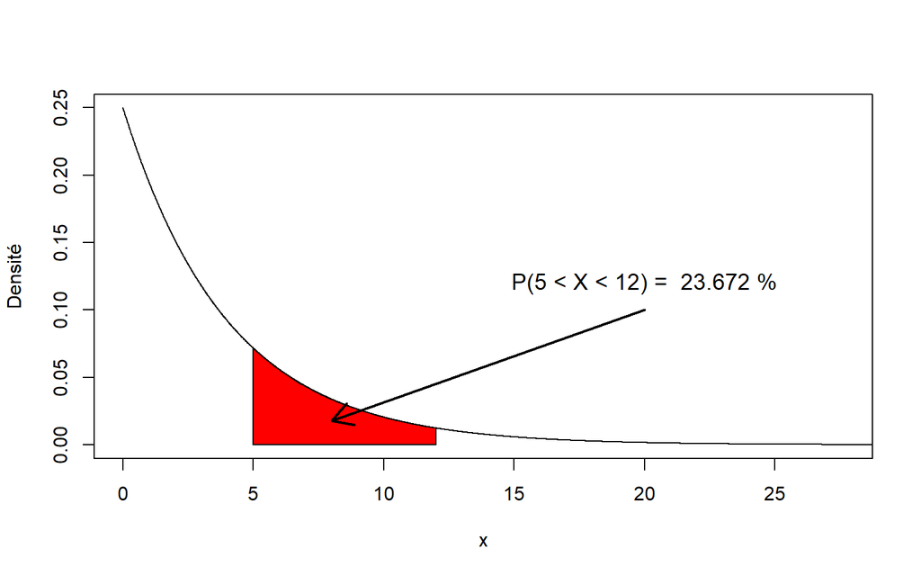

Figure 7.30: Distribution exponentielle

```r
exp_area(rate=0.25, lb=5, ub=12, acolor="red")

tx <- paste("P(5 < X < 12) = ",round(100*(pr1-pr2),3),"%")
text(20, 0.12, tx, col = "black", cex = 1.2)
arrows(20, 0.1, 8, 0.018, length=0.2, lwd=2)
```

## 7.6 Conclusion

Dans cette section, nous avons appris à générer des données qualitatives (nominales et ordinales) et quantitatives (d’intervalle et de rapport). Les distributions des scores générés ont été décrites à l’aide d’indices de tendance centrale, de dispersion et de symétrie et de voussure (forme de la distribution). L’ensemble de ces acquis sont à la base de tout ce qui suit.

Une étape importante a également été franchie. Comme ce fut le cas dans le chapitre 2, où plusieurs distributions de données discrètes ont été étudiées, d’abord de manière empirique, par simulation, et ensuite de manière analytique, les distributions continues uniforme, normale et exponentielle ont été mises à l’étude. L’ensemble constitue l’essentiel de ce dont nous aurons besoin dans les chapitres suivants.

## 7.7 Références

1. KVALSETH, TARALD O., Measuring variation for nominal data, Bulletin of the Psychonomic Society, 1988. 26 (5), 433-436
2. REYNOLDS, H. T. The analysis of cross-classifications. New York: Free Press, 1977
3. TASTLE, William J. & Wierman, Mark J., Consensus and dissention: A measure of ordinal dispersion, International Journal of Approximate Reasoning 45 (2007) 531–545

## 7.8 Solutions aux exercices

### 7.8.1 Exercice 1

1. Chargez la librairie **wakefield**:

```r
library(wakefield)
```

```r
n = 500
empl = employment(500, x = c("Plein Temps", "Temps Partiel",
    "Sans Emploi", "Retraite", "Etude"), prob = c(0.6, 0.15,
    0.1, 0.15, 0.1), name = "Emploi")
```

3. Obtenez un diagramme en barres pour représenter ces données. Notez que vous devez obtenir le tableau de fréquences au préalable.

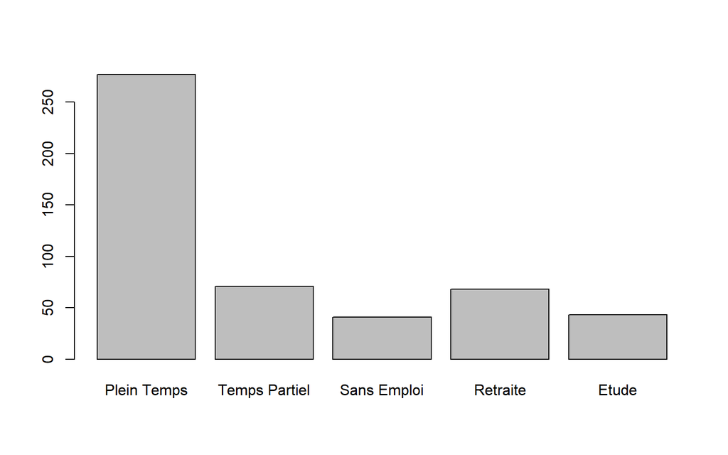

```r
tbl = table(empl)
barplot(tbl)
```

4. Construisez un diagramme en secteur pour représenter les proportions des différents statuts d’emploi.

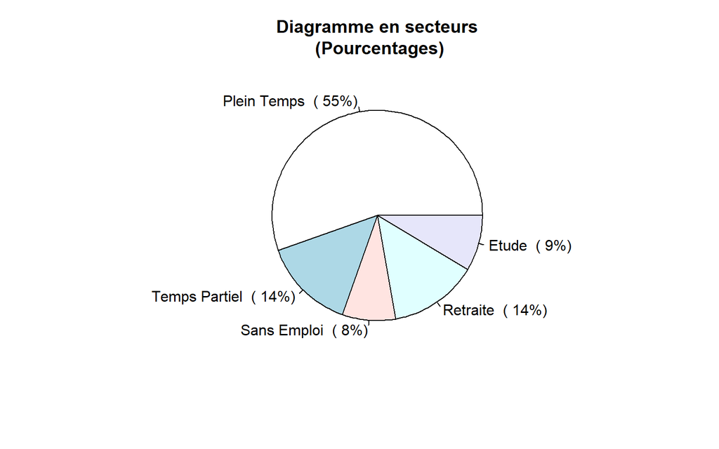

```r
slices <- tbl
lbls <- c("Plein Temps", "Temps Partiel",
          "Sans Emploi", "Retraite", "Etude")
pct <- round(slices/sum(slices)*100)
lbls <- paste(lbls," (", pct)
lbls <- paste(lbls,"%)",sep="")
pie(slices,
    labels = lbls,
    main="Diagramme en secteurs\n (Pourcentages)")
```

5. Déterminez le mode de cette distribution, en utilisant la fonction **Mode()*** de la librairie **DescTools**. Dans ce cas, le mode est déterminé à partir des données originales (**x**). Puis, refaites le travail en utilisant la fonction **modes()** de la librairie **agrmt**. Dans ce cas, le mode est calculé à partir du tableau de fréquences.

```r
library(DescTools)
library(agrmt)
Mode(empl)
```

```
#> [1] Plein Temps
#> attr(,"freq")
#> [1] 277
#> Levels: Plein Temps Temps Partiel Sans Emploi Retraite Etude
```

```r
tbl = table(empl)
modes(tbl)
```

```
#> $at
#> [1] 1 2 3 4 5
#>
#> $frequencies
#> empl
#>   Plein Temps Temps Partiel   Sans Emploi      Retraite         Etude
#>           277            71            41            68            43
#>
#> $mode
#> [1] 1
#>
#> $positions
#> [1] 1
#>
#> $contiguous
#> [1] TRUE
```

### 7.8.2 Exercice 2

1. Utilisez la fonction **likert_7()** de la librairie **wakefield** afin de générer 500 données ordinales dont les attributs sont les 7 points suivants:
- “Parfaitement d’accord”
- “D’accord”
- “Un peu d’accord”
- “Neutre”
- “Un peu en désaccord”
- “En désaccord”
- “Parfaitement en désaccord”

Faites en sorte que les proportions des “accords” soient plus élevées que les proportions de “désaccord”. Le nom de la variable générée sera: OPINION

```r
library(wakefield)
n = 500
x = likert_7(n, x = c("Parfaitement d'accord", "D'accord", "Un peu d'accord",
    "Neutre", "Un peu en désaccord", "En désaccord", "Parfaitement en désaccord"),
    prob = c(6, 8, 3, 2, 3, 3, 2), name = "Opinion")
```

2. Obtenez des représentations graphiques de cet ensemble de données: diagramme en barres et diagramme en boîte.

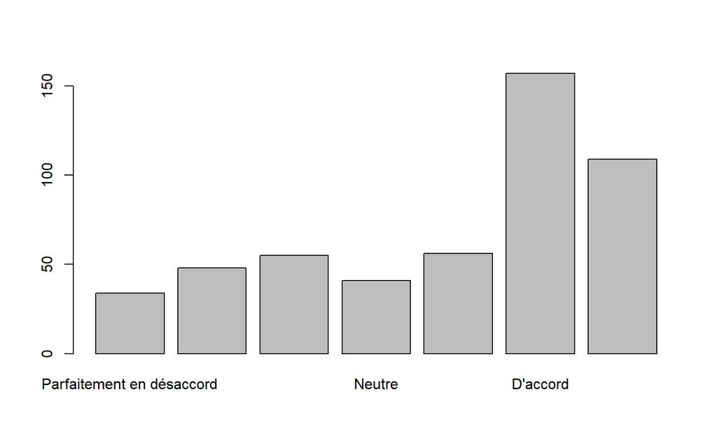

```r
tbl = table(x)
barplot(tbl)
```

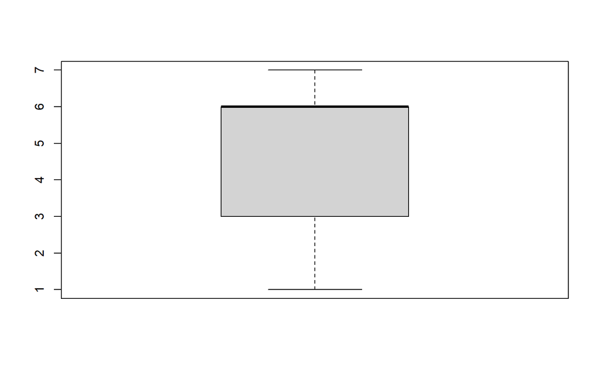

```r
boxplot(x)
```

3. Calculez la médiane de cet ensemble de données (essayez plusieurs méthodes)

```r
library(plyr)
categor = c("Parfaitement d'accord", "D'accord", "Un peu d'accord",
    "Neutre", "Un peu en désaccord", "En désaccord", "Parfaitement en désaccord")
xrec = as.numeric(mapvalues(x, from = categor, to = c(1:7)))

median(xrec)
```

```
#> [1] 6
```

```r
summary(xrec)
```

```
#>    Min. 1st Qu.  Median    Mean 3rd Qu.    Max.
#>   1.000   3.000   6.000   4.888   6.000   7.000
```

```r
quantile(xrec, 0.5)
```

```
#> 50%
#>   6
```

```r
library(psych)
t(describe(xrec))
```

```
#>                   X1
#> vars       1.0000000
#> n        500.0000000
#> mean       4.8880000
#> sd         1.9117441
#> median     6.0000000
#> trimmed    5.0700000
#> mad        1.4826000
#> min        1.0000000
#> max        7.0000000
#> range      6.0000000
#> skew      -0.6613805
#> kurtosis  -0.8676030
#> se         0.0854958
```

### 7.8.3 Exercice 3

1. Reprenez la variable EMPLOI générée antérieurement:

```r
n = 500
x = employment(n, x = c("Plein Temps", "Temps Partiel", "Sans Emploi",
    "Retraite", "Etude"), prob = c(0.5, 0.15, 0.1, 0.15, 0.1),
    name = "Variable")
```

2. Examinez les indices de dispersion pour cette variable nominale. Comment qualifieriez-vous cette distribution? (NOTE: la librairie **DescTools** est nécessaire ici!)

```r
library(DescTools)

tbl = table(x)
N = sum(tbl)
tbl
```

```
#> x
#>   Plein Temps Temps Partiel   Sans Emploi      Retraite         Etude
#>           267            68            46            71            48
```

```r
mode = Mode(x)            # Détermination du/des mode(s)
nomode = length(mode)
distmode = c("Unimodale","Bimodale","Multimodale")
if(nomode>2){nomode = 3}
cat("Catégorie(s) Modale(s) = ",Mode(x))
```

```
#> Catégorie(s) Modale(s) =  1
```

```r
cat("La distribution est ",distmode[nomode])
```

```
#> La distribution est  Unimodale
```

```r
VarRat = 1-length(mode)*max(tbl)/N    # Rapport de Variation
cat("Rapport de Variation = ",VarRat)
```

```
#> Rapport de Variation =  0.466
```

```r
k = length(tbl)
N = sum(tbl)
xs = sort(tbl,descending=FALSE)
DMM = 1-(sum(xs[k]-xs[1:k-1]))/(N*(k-1))
cat("DMM = ",DMM)
```

```
#> DMM =  0.5825
```

```r
IVQ = (k/(k-1))*(1-sum((tbl/N)**2))
cat("IQV = ",IVQ)
```

```
#> IQV =  0.82313
```

```r
IER = -sum((tbl/sum(tbl))*log(tbl/sum(tbl)))/log(k)
cat("IER = ",IER)
```

```
#> IER =  0.8251287
```

```r
ETM = 1-sqrt(1/((k-1)*N^2)*sum((xs[k]-xs)^2))
cat("ETM = ",ETM)
```

```
#> ETM =  0.5818864
```

### 7.8.4 Exercice 4

1. Reprenez la variable **ord** générée antérieurement:

```r
library(wakefield)
ord = r_sample_ordered(n=50, c(1:7),
                       prob = NULL, name = "Réponse")
head(ord,10)
```

```
#>  [1] 6 3 1 7 3 5 2 2 6 1
#> Levels: 7 < 6 < 5 < 4 < 3 < 2 < 1
```

```r
ord = as.numeric(ord)
cat("La médiane est égale à ",median(ord))
```

```
#> La médiane est égale à  4
```

2. Obtenez un diagramme en barres pour cette variable. Quelle est votre perception initiale concernant la dispersion de cette variable?

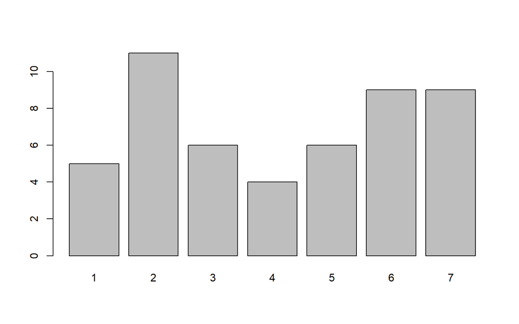

```r
barplot(table(ord))
```

3. Obtenez un diagramme en boîte pour ces données. Votre appréciation de la dispersion change-t-elle?

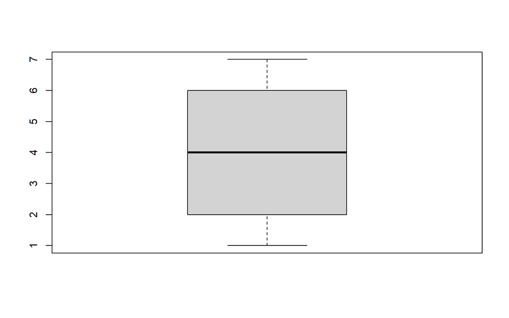

```r
boxplot(ord)
```

4. Calculez l’intervalle inter-quartile et prenez-en note pour les exercices suivants.

```r
IQR(ord)
```

```
#> [1] 4
```

5. Obtenez la mesure de consensus pour cette variable, et qualifiez la dispersion à partir du résultat obtenu. Prenez-en note pour les exercices suivants.

```r
library(agrmt)
consensus(table(ord))
```

```
#> [1] 0.4224043
```

6. Générez une nouvelle variable ordinale en utilisant le même processus générateur, mais en altérant les probabilités associées à chaque attribut possible:

```r
library(wakefield)
ord = r_sample_ordered(n=50, c(1:7),
                       prob = c(10,8,2,0,2,8,10),
                       name = "Réponse")
ord = as.numeric(ord)
```

1. Obtenez la médiane de cette variable

```r
cat("Médiane = ",median(ord))
```

```
#> Médiane =  5.5
```

2. Calculez l’écart inter-quartile pour ces données

```r
cat("EIQ = ",IQR(ord))
```

```
#> EIQ =  4
```

3. Obtenez un diagramme en barres pour cette variable

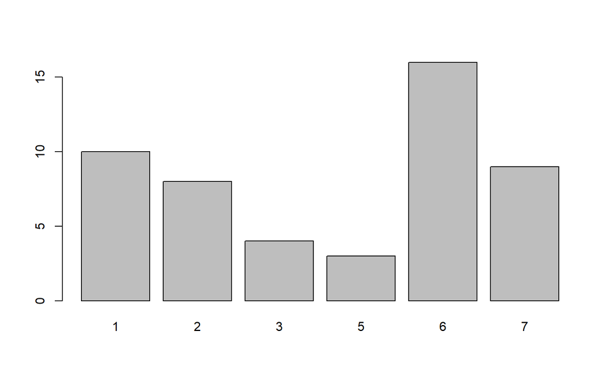

```r
barplot(table(ord))
```

4. Quelle est votre perception de la dispersion de cette variable?
5. Obtenez la mesure de consensus pour cette variable, et qualifiez la dispersion à partir du résultat obtenu.

```r
library(agrmt)
consensus(table(ord))
```

```
#> [1] 0.357867
```

7. Générez une nouvelle variable ordinale en utilisant le même processus générateur, mais en altérant les probabilités associées à chaque attribut possible:

```r
library(wakefield)
ord = r_sample_ordered(n=50, c(1:7),
                       prob = c(1,0,1,0,4,8,10),
                       name = "Réponse")
ord = as.numeric(ord)
```

1. Obtenez la médiane de cette variable

```r
cat("Médiane de ord = ",median(ord))
```

```
#> Médiane de ord =  2
```

2. Calculez l’écart inter-quartile pour ces données

```r
cat("EIQ de ord = ",IQR(ord))
```

```
#> EIQ de ord =  2
```

3. Obtenez un diagramme en barres pour cette variable

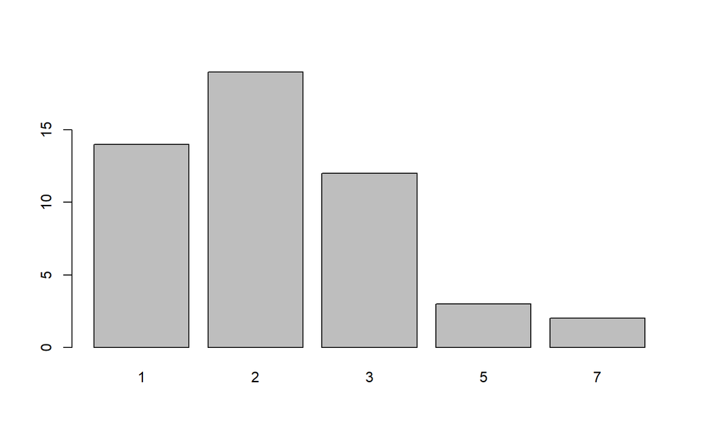

```r
barplot(table(ord))
```

4. Obtenez un diagramme en boîte pour cette variable

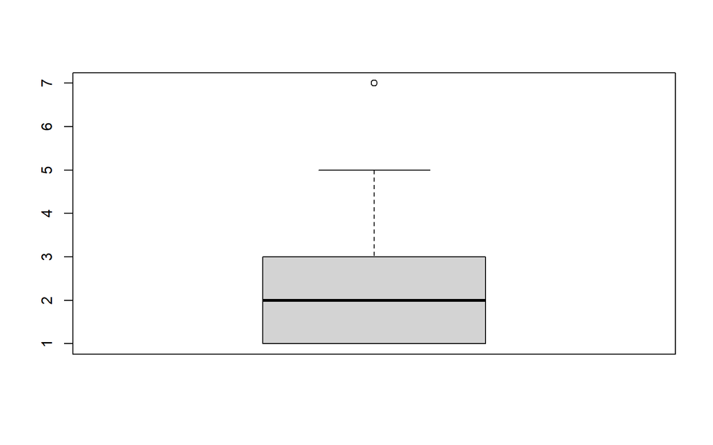

```r
boxplot(ord)
```

5. Quelle est votre perception de la dispersion de cette variable?
6. Obtenez la mesure de consensus pour cette variable, et qualifiez la dispersion à partir du résultat obtenu.

```r
library(agrmt)
consensus(table(ord))
```

```
#> [1] 0.6293081
```

8. Faites l’expérience de différentes distributions en modifiant, dans le code R utilisé ci-dessus, les probabilités des différents attributs. Le vecteur définissant **prob=** correspond aux poids accordés aux attributs 1 à 7. Les probabilités sont simplement les poids relatifs: **prob/sum(prob)**. Expérimentez différentes configurations pour apprécier le fonctionnement de l’indice de consensus. Comparez les intervalles inter-quartiles obtenus dans chaque cas, avec celui obtenu en (4). Comparez de la même manière les indices de consensus.

### 7.8.5 Exercice 5:

1. **Générez un ensemble de 500 observations gaussiennes avec une moyenne avoisinant 50 et un écart-type avoisinants 10.**

```r
x = rnorm(500,50,10)
head(x,10)
```

```
#>  [1] 53.48917 47.59013 48.58124 53.98656 52.83430 46.46080 75.75439 49.06561
#>  [9] 44.06522 41.67717
```

2. **Obtenez les indices de tendance centrale: moyenne et médiane**

```r
cat("Moyenne = ",mean(x))
```

```
#> Moyenne =  49.7467
```

```r
cat("Médiane = ",median(x))
```

```
#> Médiane =  49.43911
```

3. **Obtenez les indices de dispersion**

```r
cat("Écart Inter-Quartile = ",IQR(x))
```

```
#> Écart Inter-Quartile =  14.0282
```

```r
cat("Déviation Moyenne    = ",mad(x,center=median(x)))
```

```
#> Déviation Moyenne    =  10.43891
```

```r
cat("Déviation moyenne    = ",mad(x,center=mean(x)))
```

```
#> Déviation moyenne    =  10.46915
```

```r
cat("Variance             = ",var(x))
```

```
#> Variance             =  97.99199
```

```r
cat("Écart-Type           = ",sd(x))
```

```
#> Écart-Type           =  9.89909
```

4. **Obtenez les indices de symétrie et de voussure**

```r
library(moments)
cat("Indice de symétrie  = ",skewness(x))
```

```
#> Indice de symétrie  =  -0.01854912
```

```r
cat("Indice de voussure  = ",kurtosis(x))
```

```
#> Indice de voussure  =  2.693011
```

5. **Obtenez la distribution des fréquences et les représentations graphiques habituelles**

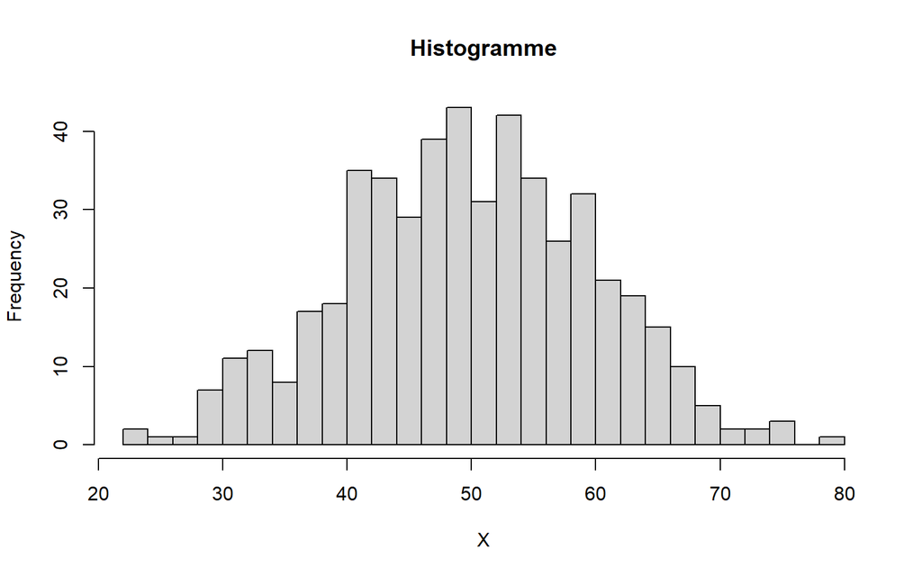

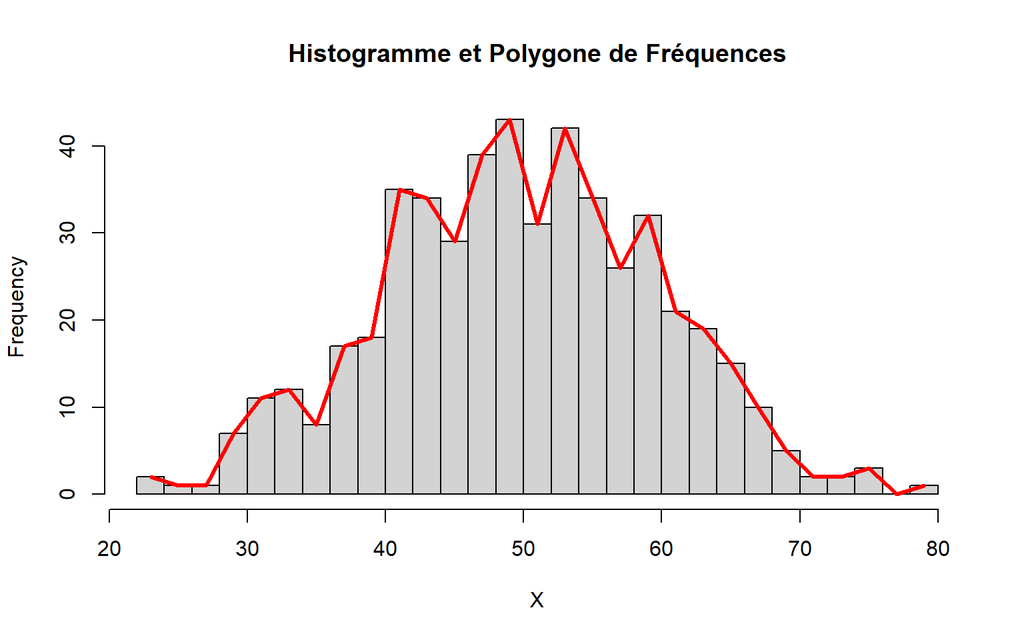

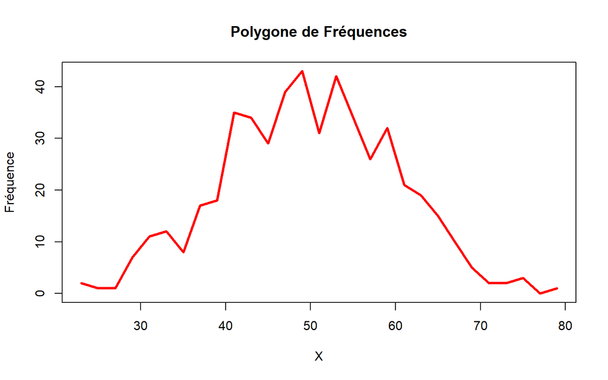

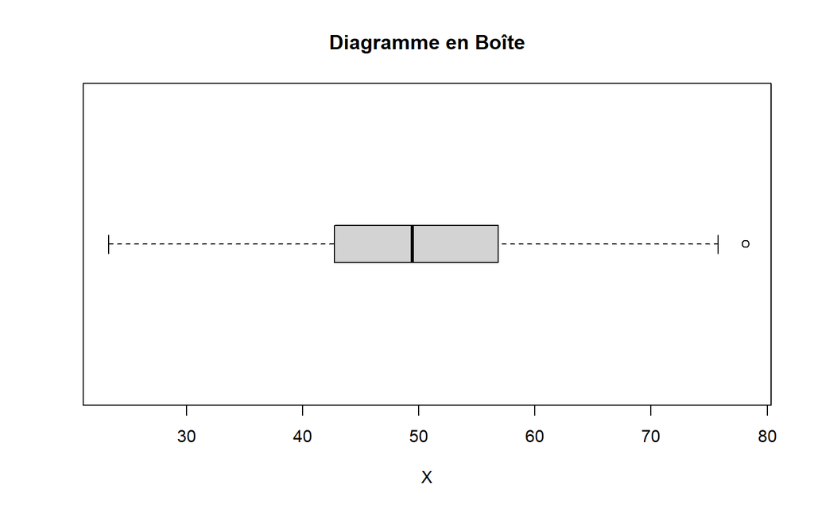

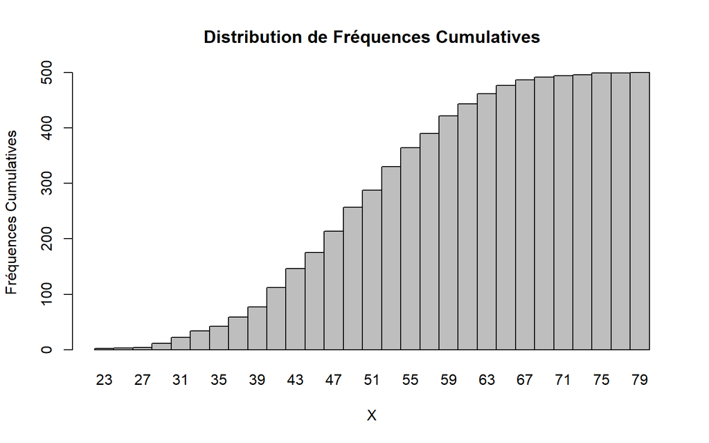

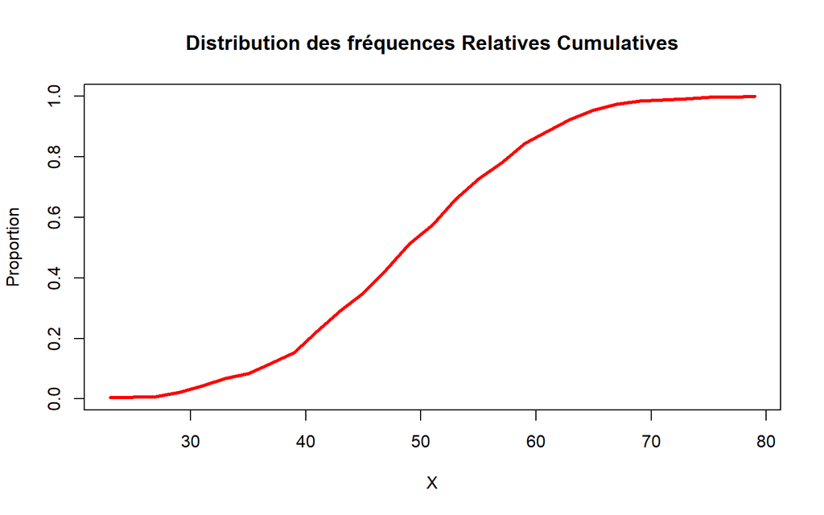

```r
TF = TblFreq2(x)
```

```r
kable(TF, booktabs=TRUE, caption="Distribution de Fréquences") %>%
kable_styling(full_width = TRUE)
```

Distribution de Fréquences

| LimInf | LimSup | FreqAbs | FreqRel | FreqCum | FreqRelCum |
| --- | --- | --- | --- | --- | --- |
| 21.5 | 23.5 | 2 | 0.004 | 2 | 0.004 |
| 23.5 | 25.5 | 1 | 0.002 | 3 | 0.006 |
| 25.5 | 27.5 | 1 | 0.002 | 4 | 0.008 |
| 27.5 | 29.5 | 7 | 0.014 | 11 | 0.022 |
| 29.5 | 31.5 | 11 | 0.022 | 22 | 0.044 |
| 31.5 | 33.5 | 12 | 0.024 | 34 | 0.068 |
| 33.5 | 35.5 | 8 | 0.016 | 42 | 0.084 |
| 35.5 | 37.5 | 17 | 0.034 | 59 | 0.118 |
| 37.5 | 39.5 | 18 | 0.036 | 77 | 0.154 |
| 39.5 | 41.5 | 35 | 0.070 | 112 | 0.224 |
| 41.5 | 43.5 | 34 | 0.068 | 146 | 0.292 |
| 43.5 | 45.5 | 29 | 0.058 | 175 | 0.350 |
| 45.5 | 47.5 | 39 | 0.078 | 214 | 0.428 |
| 47.5 | 49.5 | 43 | 0.086 | 257 | 0.514 |
| 49.5 | 51.5 | 31 | 0.062 | 288 | 0.576 |
| 51.5 | 53.5 | 42 | 0.084 | 330 | 0.660 |
| 53.5 | 55.5 | 34 | 0.068 | 364 | 0.728 |
| 55.5 | 57.5 | 26 | 0.052 | 390 | 0.780 |
| 57.5 | 59.5 | 32 | 0.064 | 422 | 0.844 |
| 59.5 | 61.5 | 21 | 0.042 | 443 | 0.886 |
| 61.5 | 63.5 | 19 | 0.038 | 462 | 0.924 |
| 63.5 | 65.5 | 15 | 0.030 | 477 | 0.954 |
| 65.5 | 67.5 | 10 | 0.020 | 487 | 0.974 |
| 67.5 | 69.5 | 5 | 0.010 | 492 | 0.984 |
| 69.5 | 71.5 | 2 | 0.004 | 494 | 0.988 |
| 71.5 | 73.5 | 2 | 0.004 | 496 | 0.992 |
| 73.5 | 75.5 | 3 | 0.006 | 499 | 0.998 |
| 75.5 | 77.5 | 0 | 0.000 | 499 | 0.998 |
| 77.5 | 79.5 | 1 | 0.002 | 500 | 1.000 |

6. **Sous quel score trouve-t-on 67% de la distribution?**

```r
cat("P67 = ",x[0.67*length(x)])
```

[output not shown]

7. **Quelle est la proportion des scores de la distribution sous X = 40?**

```r
cat("RC40 = ",sum(x<=40)/length(x))
```

```
#> RC40 =  0.154
```

```r
cat("P[(x<35) ou (x>57)] = ",sum((x<35)|(x>70))/length(x))
```

[output not shown]

9. **Déterminez les valeurs limitant les 95% centraux de la distribution.**

```r
cat("P[",quantile(x,0.025),"< x < ",quantile(x,0.975),"] = 0.95")
```

```
#> P[ 30.62804 < x <  67.9194 ] = 0.95
```

10. **Quelle est la proportion des scores compris entre 38 et 57?**

```r
cat("P[38 < x < 57] = ",sum((x>=38)&(x<=57))/length(x))
```

```
#> P[38 < x < 57] =  0.636
```